# easy geom recipes

Evangeline Reynolds, Morgan Brown

2022/03/01, revised 2024/05/06

Using ggplot2 has been described as writing ‘graphical poems’. But we may feel at a loss for ‘words’ when functions we’d like to have don’t exist. The ggplot2 extension system allows us to build new ‘vocabulary’ for fluent expression.

An exciting extension mechanism is that of inheriting from existing, more primitive geom behavior after performing some calculation.

To get your feet wet in this world and give you a taste of patterns for geom extension, we provide three basic examples of the geoms_ that use *primitive* geoms (GeomPoint, GeomText, GeomSegment, etc) along with a practice exercise. With such geom_ (or stat_) functions, calculation is done under the hood by the ggplot2 system. You may only be familiar with the user-facing geom_point(), geom_text(), geom_segment() layer functions that use these more primitive objects under the hood, and that’s okay - this should give you enough intuition for using primitives.

With these geom_ functions, you can write *new* graphical poems with concise new ‘words’ you’ve designed yourself!

This tutorial is intended for individuals who already have a solid working knowledge of the syntax of ggplot2 but may like to build a richer vocabulary for themselves.

# Overview

Our recipes take the form:

- *Step 0. Get the job done with ‘base’ ggplot2.* It’s a good idea to clarify what needs to happen without getting into the extension architecture
- *Step 1.a Write a computation function.* Wrap the necessary computation into a function that your target geom_*() function will perform. We focus on ‘compute_group’ computation only in this tutorial.
- *Step 1.b Test using prepped data*
- *Step 2.a Define a Stat* ggproto objects allow your extension to work together with base ggplot2 functions! You’ll use the computation function from step 1 to help define it.
- *Step 2.b Test using `layer()`*
- *Step 3.a Write your user-facing geom_ function!* You’re ready to write your function. You will incorporate the ggproto from Step 2 and also define which more primitive geom (point, text, segment etc) you want other behaviors to inherit from.
- *Step 3.b Test. Enjoy!* Take your new geom for a spin! Check out group-wise computation behavior!

Below, you’ll see a completely worked example (example recipes A, B and C) and then a invitation to build a related target geom_*() (Tasks A, B, and C).

# Example recipe #A: `geom_point_xy_medians()`

–

- This will be a point at the median of x and y

## Step 0: use base ggplot2 to get the job done

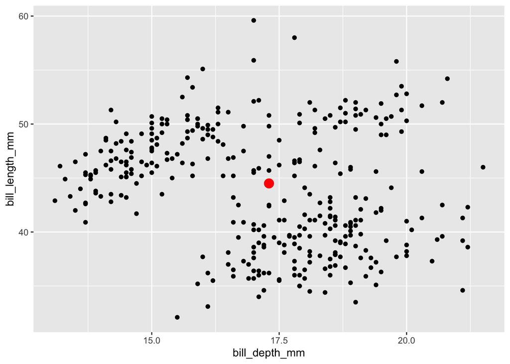

```r
library(tidyverse)
library(palmerpenguins)
penguins <- remove_missing(penguins)


penguins_medians <- penguins %>%
  summarize(bill_length_mm_median = median(bill_length_mm),
            bill_depth_mm_median = median(bill_depth_mm))

penguins %>%
  ggplot() +
  aes(x = bill_depth_mm) +
  aes(y = bill_length_mm) +
  geom_point() +
  geom_point(data = penguins_medians,
    color = "red", size = 4,
             aes(x = bill_depth_mm_median,
                 y = bill_length_mm_median))
```

## Step 1a: write compute function

```r
# Step 1.a
compute_group_xy_medians <- function(data, scales){ #  scales is used internally in ggplot2
  data %>%
    summarize(x = median(x),
            y = median(y))
}
```

## Step 1b. Test compute

```r
penguins |>
  select(x = bill_depth_mm,       # ggplot2 will work with 'aes' column names
         y = bill_length_mm) |>  # therefore select is required to used the compute function
  compute_group_xy_medians()
```

```
## # A tibble: 1 × 2
##       x     y
##   <dbl> <dbl>
## 1  17.3  44.5
```

## Step 2: define new Stat

Things to notice

- what’s the naming convention for the proto object?
- which aesthetics are required as inputs?
- where does the function from above go?

```r
StatXymedians <- ggplot2::ggproto(`_class` = "StatXymedians",
                                  `_inherit` = ggplot2::Stat,
                                  required_aes = c("x", "y"),
                                  compute_group = compute_group_xy_medians)
```

## Step 3a: define geom_* function

Things to notice

- Where does our work up to this point enter in?
- What more primitive geom will we inherit behavior from?

```r
geom_point_xy_medians <- function(
  mapping = NULL, # global aesthetics will be used if NULL
  data = NULL, # global data will be used if NULL
  position = "identity",
  na.rm = FALSE,
  show.legend = NA,
  inherit.aes = TRUE,
  ...   # many other arguments can be used specific to
        # the Geom thats used in layer and to computation definition
  ) {

  ggplot2::layer(
    stat = StatXymedians,
    geom = ggplot2::GeomPoint,
    data = data,
    mapping = mapping,
    position = position,
    show.legend = show.legend,
    inherit.aes = inherit.aes,
    params = list(na.rm = na.rm, ...)
  )

}
```

## Step 3b: Test. Enjoy! Use your function

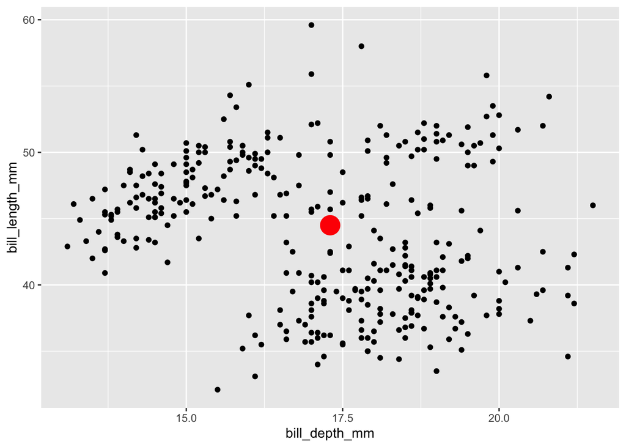

```r
penguins |>
  ggplot() +
  aes(x = bill_depth_mm, y = bill_length_mm)+
  geom_point()+
  geom_point_xy_medians(color = "red", size = 7)
```

### And check out conditionality!

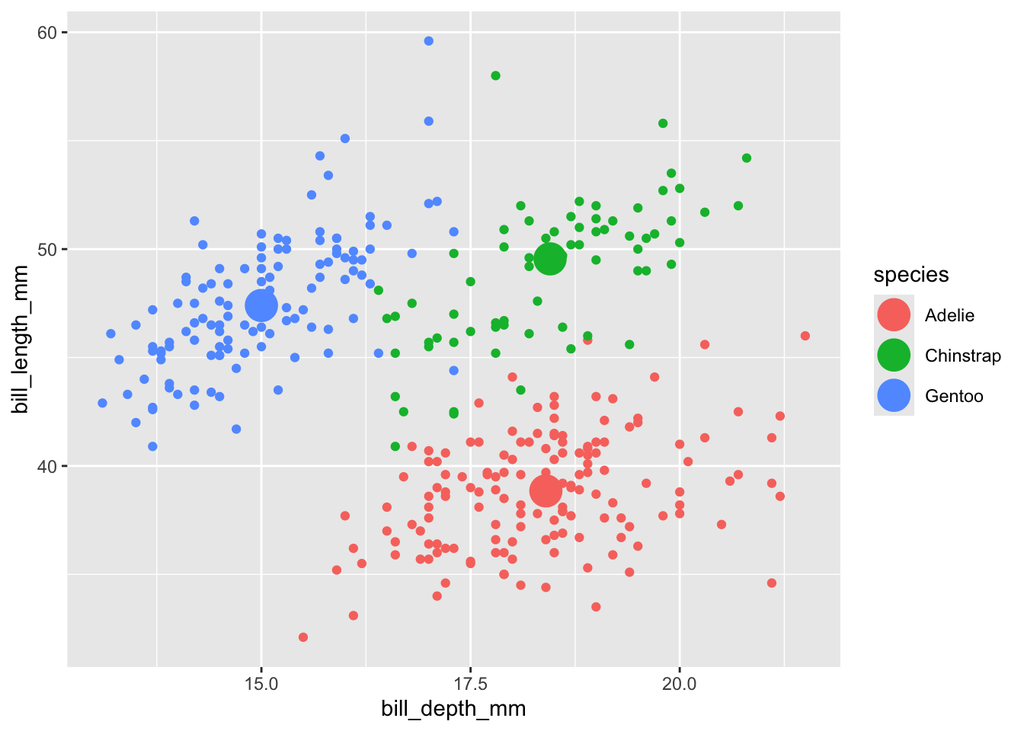

```r
penguins |>
  ggplot()+
  aes(x = bill_depth_mm,
      y = bill_length_mm,
      color = species)+
  geom_point()+
  geom_point_xy_medians(size = 7)
```